# F Test p-values

September 23, 2019

## F tests: Iris example

Suppose we have 3 flowers of each iris species, and we want to conduct an F test of \(H_0: \mu_1 = \mu_2 = \mu_3\).

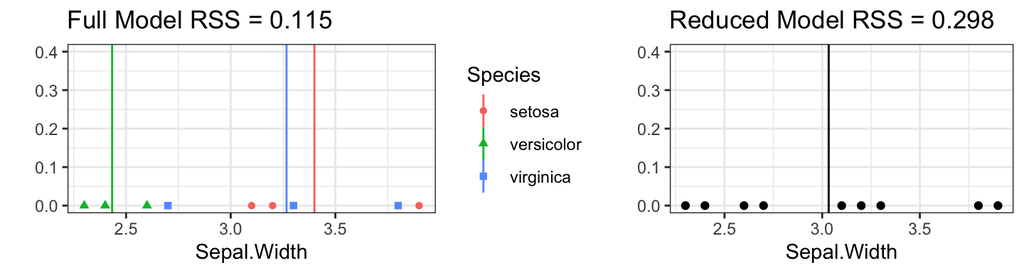

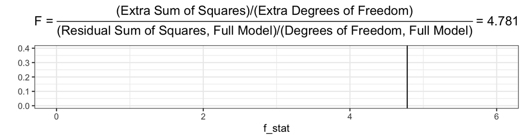

## Heading towards a p-value

p-value: If \(H_0\) is correct, what proportion of samples would give you F statistics at least as extreme as the F statistic of 4.78 we got from our actual data?

Let's simulate a fake data set, assuming \(H_0\) is true. We have 9 observations drawn at random from a Normal(3.033, 0.579) distribution.

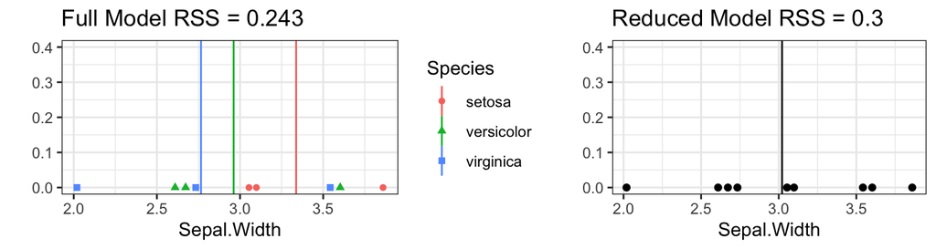

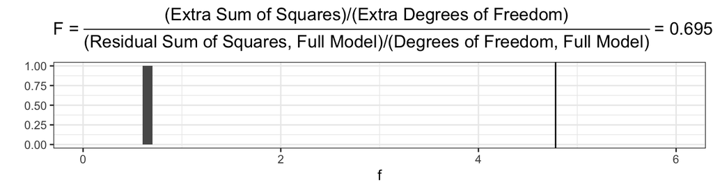

## Heading towards a p-value

p-value: If \(H_0\) is correct, what proportion of samples would give you F statistics at least as extreme as the F statistic of 4.78 we got from our actual data?

Let's simulate a fake data set, assuming \(H_0\) is true. We have 9 observations drawn at random from a Normal(3.033, 0.579) distribution.

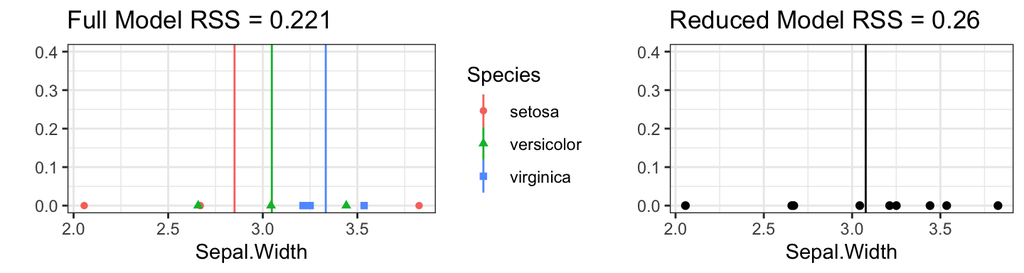

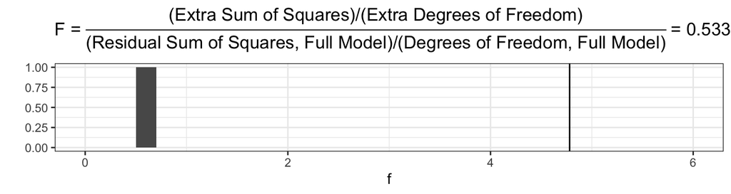

## Heading towards a p-value

p-value: If \(H_0\) is correct, what proportion of samples would give you F statistics at least as extreme as the F statistic of 4.78 we got from our actual data?

Let's simulate a fake data set, assuming \(H_0\) is true. We have 9 observations drawn at random from a Normal(3.033, 0.579) distribution.

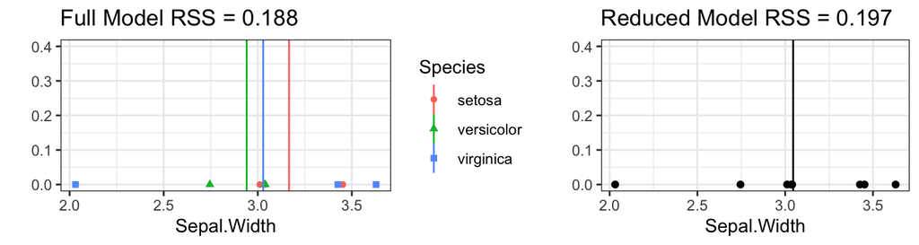

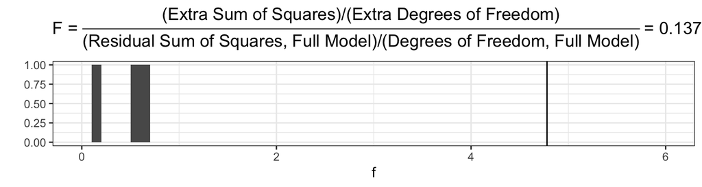

## Heading towards a p-value

p-value: If \(H_0\) is correct, what proportion of samples would give you F statistics at least as extreme as the F statistic of 4.78 we got from our actual data?

Let's simulate a fake data set, assuming \(H_0\) is true. We have 9 observations drawn at random from a Normal(3.033, 0.579) distribution.

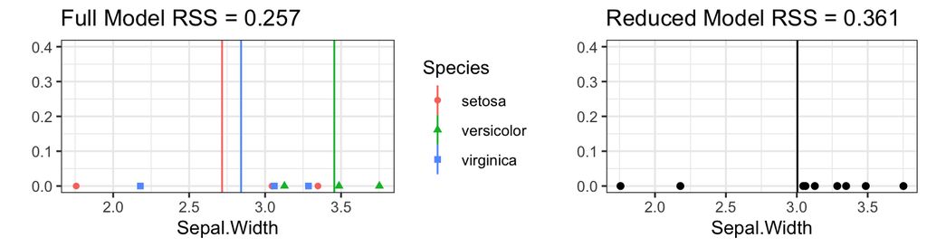

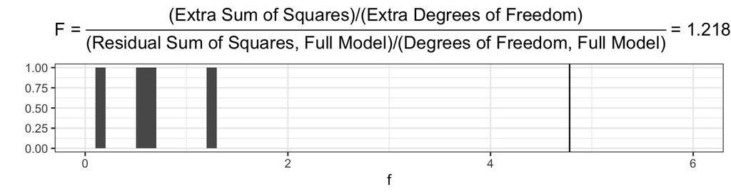

## Heading towards a p-value

p-value: If \(H_0\) is correct, what proportion of samples would give you F statistics at least as extreme as the F statistic of 4.78 we got from our actual data?

Let's simulate a fake data set, assuming \(H_0\) is true. We have 9 observations drawn at random from a Normal(3.033, 0.579) distribution.

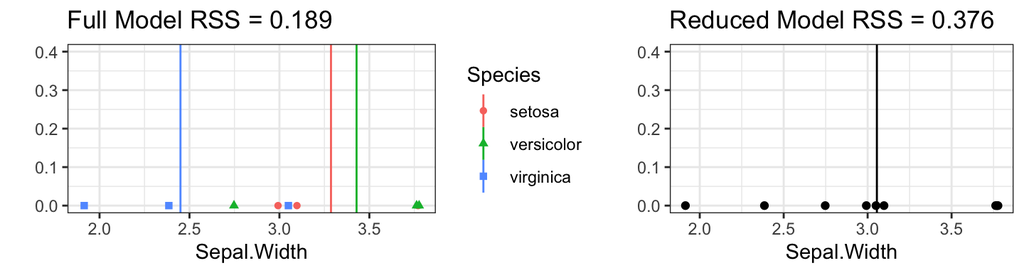

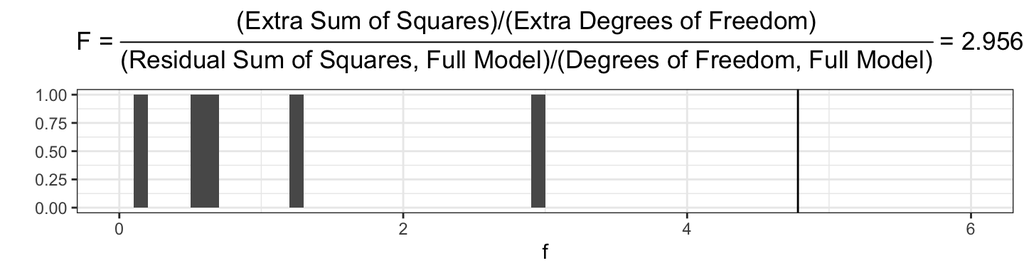

## Heading towards a p-value

p-value: If \(H_0\) is correct, what proportion of samples would give you F statistics at least as extreme as the F statistic of 4.78 we got from our actual data?

Let's simulate a fake data set, assuming \(H_0\) is true. We have 9 observations drawn at random from a Normal(3.033, 0.579) distribution.

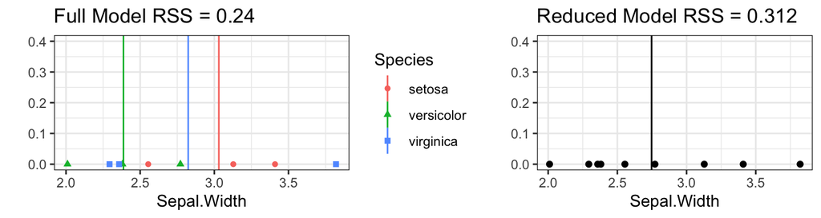

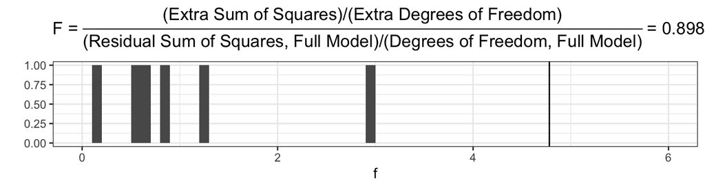

## Heading towards a p-value

p-value: If \(H_0\) is correct, what proportion of samples would give you F statistics at least as extreme as the F statistic of 4.78 we got from our actual data?

Let's simulate a fake data set, assuming \(H_0\) is true. We have 9 observations drawn at random from a Normal(3.033, 0.579) distribution.

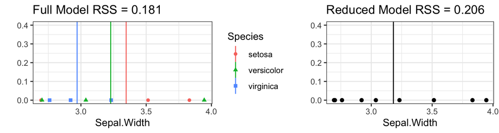

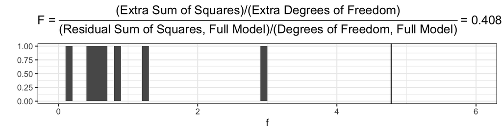

## Heading towards a p-value

p-value: If \(H_0\) is correct, what proportion of samples would give you F statistics at least as extreme as the F statistic of 4.78 we got from our actual data?

Let's simulate a fake data set, assuming \(H_0\) is true. We have 9 observations drawn at random from a Normal(3.033, 0.579) distribution.

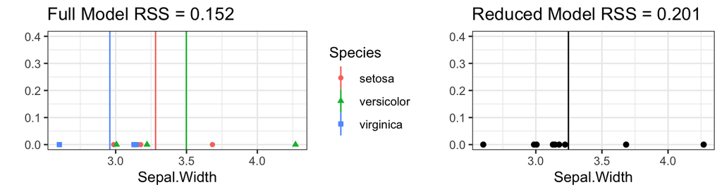

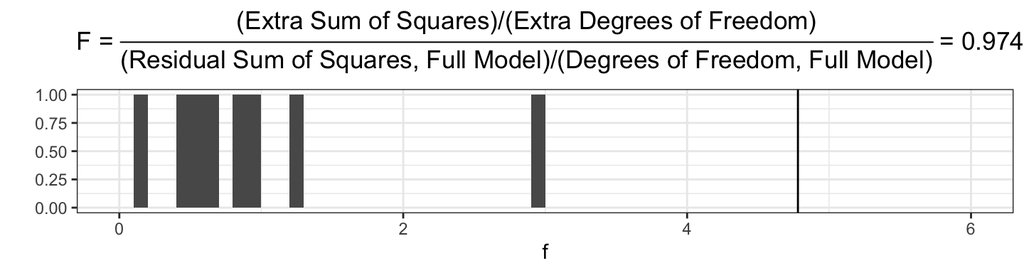

## Heading towards a p-value

p-value: If \(H_0\) is correct, what proportion of samples would give you F statistics at least as extreme as the F statistic of 4.78 we got from our actual data?

Let's simulate a fake data set, assuming \(H_0\) is true. We have 9 observations drawn at random from a Normal(3.033, 0.579) distribution.

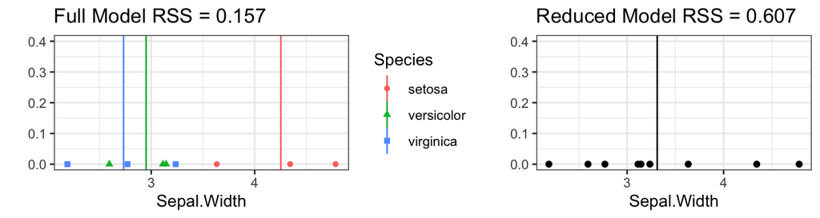

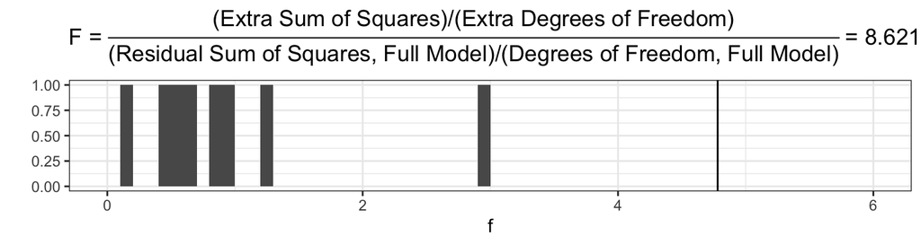

## Heading towards a p-value

p-value: If \(H_0\) is correct, what proportion of samples would give you F statistics at least as extreme as the F statistic of 4.78 we got from our actual data?

Let's simulate a fake data set, assuming \(H_0\) is true. We have 9 observations drawn at random from a Normal(3.033, 0.579) distribution.

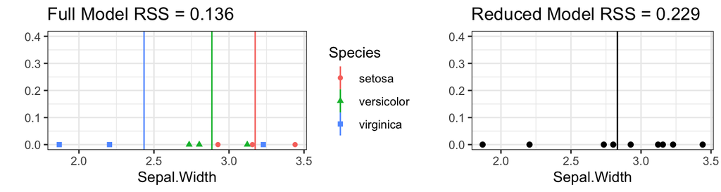

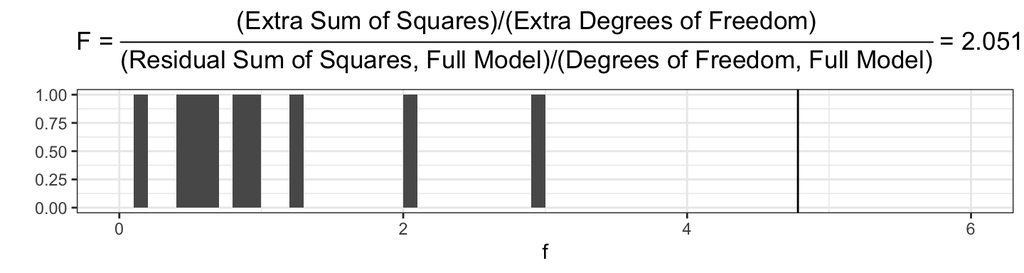

## Heading towards a p-value

p-value: If \(H_0\) is correct, what proportion of samples would give you F statistics at least as extreme as the F statistic of 4.78 we got from our actual data?

Let's simulate a fake data set, assuming \(H_0\) is true. We have 9 observations drawn at random from a Normal(3.033, 0.579) distribution.

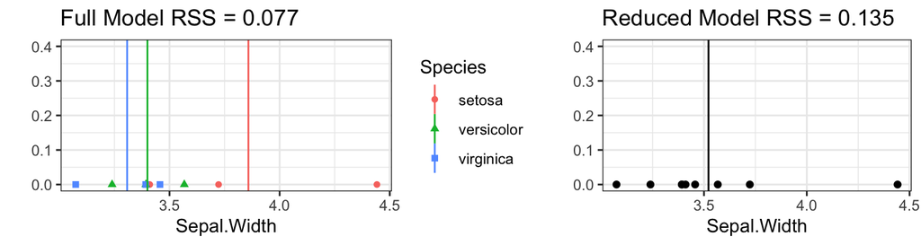

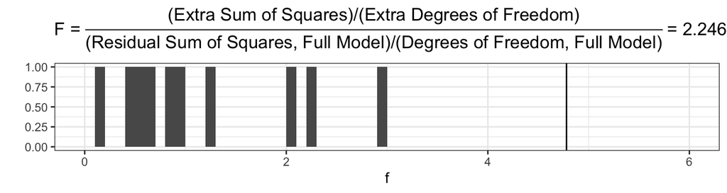

## Heading towards a p-value

p-value: If \(H_0\) is correct, what proportion of samples would give you F statistics at least as extreme as the F statistic of 4.78 we got from our actual data?

Let's simulate a fake data set, assuming \(H_0\) is true. We have 9 observations drawn at random from a Normal(3.033, 0.579) distribution.

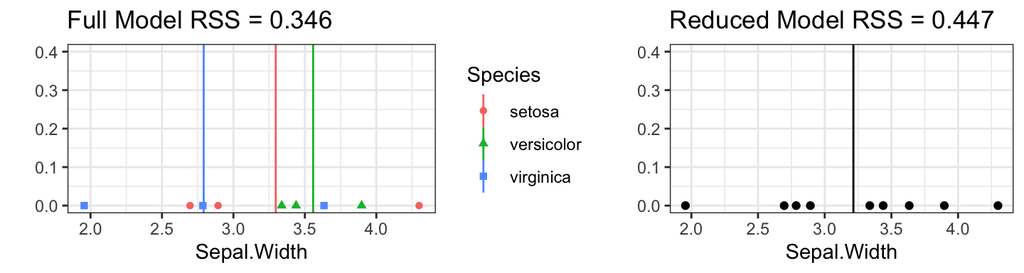

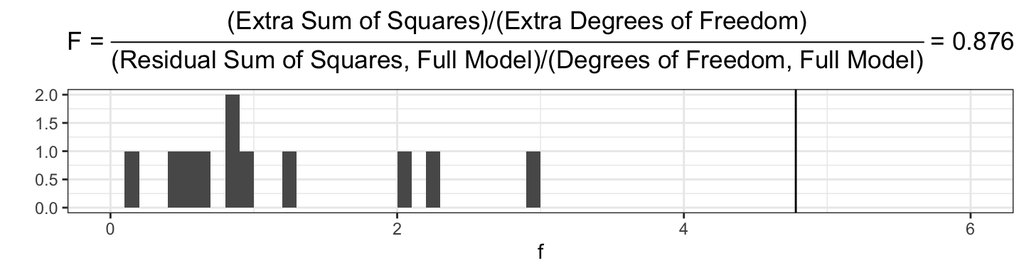

## Heading towards a p-value

p-value: If \(H_0\) is correct, what proportion of samples would give you F statistics at least as extreme as the F statistic of 4.78 we got from our actual data?

Let's simulate a fake data set, assuming \(H_0\) is true. We have 9 observations drawn at random from a Normal(3.033, 0.579) distribution.

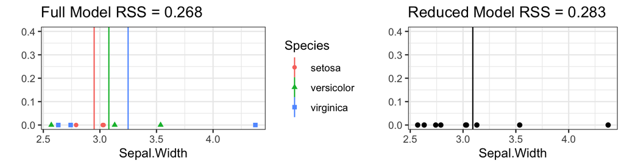

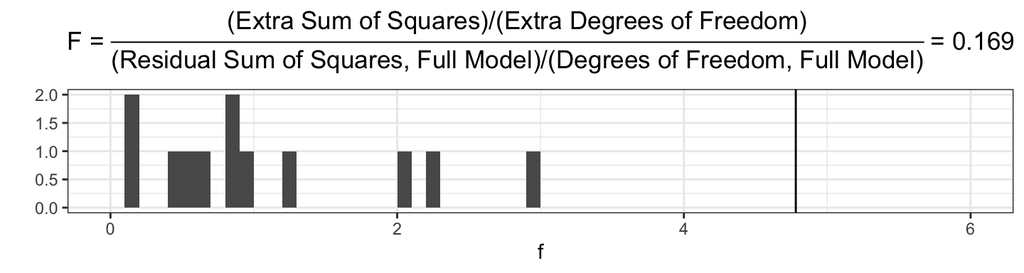

## Heading towards a p-value

p-value: If \(H_0\) is correct, what proportion of samples would give you F statistics at least as extreme as the F statistic of 4.78 we got from our actual data?

Let's simulate a fake data set, assuming \(H_0\) is true. We have 9 observations drawn at random from a Normal(3.033, 0.579) distribution.

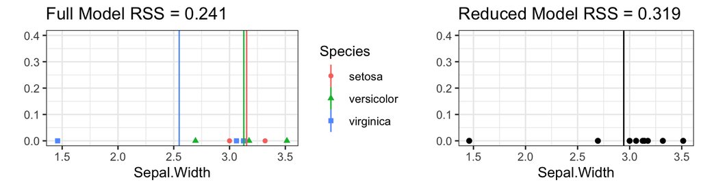

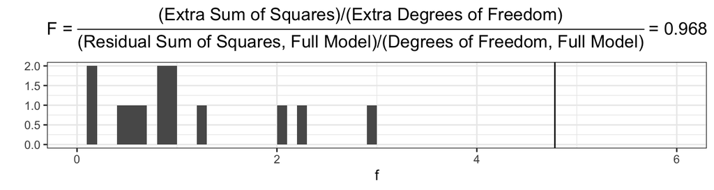